# Лабораторна робота №2. Маніпулювання даними

© [Костін Є.В.](https://github.com/NickWayne02), 2024

2024-09-08

*Мета:* Засвоєння принципів, знайомвство з інструментами та набуття навичок манпулювання даними (wrangle) засобами мови програмування R та колекції пакетів tidyverse (Hadley Wickham 2021c).

## Хід роботи

Створити реляційну БД, використовуючи СУБД SQLite. Виконати експорт даних у БД зі стандартного набору nycflights13 щодо авіаперевезень аеропорту Нью-Йорк за 2013 рік.

Налаштувати індекси: (“year,” “month,” “day”), “carrier,” “tailnum,” “dest.” Підготувати RMarkdown-документ, який би давав можливість генерувати електронний звіт з результатами виконання наступних задач:

вибрати поля year:day, dep_delay, arr_delay з таблиці flights. вибрати всі рейси з часом затримки (dep_delay) більше ніж 240 хв. Обчислити середній час затримки вильоту (dep_time) з попереднім групуванням по відстані авіамаршруту (dest). Обчислити для кожного бортового номеру літака з кількістю рейсів більше 100 середній час затримки прибуття та кількість рейсів; дані впорядкувати за убуванням часу затримки прибуття. розділити набір даних по літаках і розрахувати кількість вильотів і середню дальність польоту і затримку прибуття; побудувати графік залежності середньої затримки від середньої дальності польоту (за допомогою ggplot2). знайти кількість літаків і кількість вильотів в усі можливі пункти призначення.

## Виконання завдання

### 1. Створив реляційну БД, використовуючи СУБД SQLite.

```r
# Підключив необхідні бібліотеки
library(DBI)
library(dplyr)
library(RSQLite)
library(nycflights13)

# Створив папку Data
dataDir <- "data"
if (!dir.exists(dataDir)) {
  dir.create(dataDir)
  message("Папка створена: ", dataDir)
}

# Встановив з'єднання з базою даних
connection <- dbConnect(RSQLite::SQLite(), "data/flightsDB.sqlite3")

# Скопіював дані у БД
DBTables <- dbListTables(connection)
if (!"flights" %in% DBTables) {
  flightsDB <- copy_to(connection, nycflights13::flights, "flights",
        temporary = FALSE,
        indexes = list(
          c("year", "month", "day"),
          "carrier",
          "tailnum",
          "dest"
        )
)
} else {
  flightsDB <- tbl(connection, "flights")
}

# Вивів перші 8 рядків
head(flightsDB, 8)
```

| year | month | day | dep_time | sched_dep_time | dep_delay | arr_time | sched_arr_time | arr_delay | carrier | flight | tailnum | origin | dest | air_time | distance | hour | minute | time_hour |
| --- | --- | --- | --- | --- | --- | --- | --- | --- | --- | --- | --- | --- | --- | --- | --- | --- | --- | --- |
| 2013 | 1 | 1 | 517 | 515 | 2 | 830 | 819 | 11 | UA | 1545 | N14228 | EWR | IAH | 227 | 1400 | 5 | 15 | 1357034400 |
| 2013 | 1 | 1 | 533 | 529 | 4 | 850 | 830 | 20 | UA | 1714 | N24211 | LGA | IAH | 227 | 1416 | 5 | 29 | 1357034400 |
| 2013 | 1 | 1 | 542 | 540 | 2 | 923 | 850 | 33 | AA | 1141 | N619AA | JFK | MIA | 160 | 1089 | 5 | 40 | 1357034400 |
| 2013 | 1 | 1 | 544 | 545 | -1 | 1004 | 1022 | -18 | B6 | 725 | N804JB | JFK | BQN | 183 | 1576 | 5 | 45 | 1357034400 |
| 2013 | 1 | 1 | 554 | 600 | -6 | 812 | 837 | -25 | DL | 461 | N668DN | LGA | ATL | 116 | 762 | 6 | 0 | 1357038000 |
| 2013 | 1 | 1 | 554 | 558 | -4 | 740 | 728 | 12 | UA | 1696 | N39463 | EWR | ORD | 150 | 719 | 5 | 58 | 1357034400 |
| 2013 | 1 | 1 | 555 | 600 | -5 | 913 | 854 | 19 | B6 | 507 | N516JB | EWR | FLL | 158 | 1065 | 6 | 0 | 1357038000 |
| 2013 | 1 | 1 | 557 | 600 | -3 | 709 | 723 | -14 | EV | 5708 | N829AS | LGA | IAD | 53 | 229 | 6 | 0 | 1357038000 |

### 2. Вивів поля `year:day`, `dep_delay`, `arr_delay` з таблиці flights

```r
flightsDB %>% select(year:day, dep_delay, arr_delay)
```

| year | month | day | dep_delay | arr_delay |
| --- | --- | --- | --- | --- |
| 2013 | 1 | 1 | 2 | 11 |
| 2013 | 1 | 1 | 4 | 20 |
| 2013 | 1 | 1 | 2 | 33 |
| 2013 | 1 | 1 | -1 | -18 |
| 2013 | 1 | 1 | -6 | -25 |
| 2013 | 1 | 1 | -4 | 12 |
| 2013 | 1 | 1 | -5 | 19 |
| 2013 | 1 | 1 | -3 | -14 |
| 2013 | 1 | 1 | -3 | -8 |
| 2013 | 1 | 1 | -2 | 8 |

[output cut: 990 more lines]

### 3. Вибрав всі рейси з часом затримки (dep_delay) більше ніж 240 хв.

```r
flightsDB %>% filter(dep_delay > 240)
```

| year | month | day | dep_time | sched_dep_time | dep_delay | arr_time | sched_arr_time | arr_delay | carrier | flight | tailnum | origin | dest | air_time | distance | hour | minute | time_hour |
| --- | --- | --- | --- | --- | --- | --- | --- | --- | --- | --- | --- | --- | --- | --- | --- | --- | --- | --- |
| 2013 | 1 | 1 | 848 | 1835 | 853 | 1001 | 1950 | 851 | MQ | 3944 | N942MQ | JFK | BWI | 41 | 184 | 18 | 35 | 1357081200 |
| 2013 | 1 | 1 | 1815 | 1325 | 290 | 2120 | 1542 | 338 | EV | 4417 | N17185 | EWR | OMA | 213 | 1134 | 13 | 25 | 1357063200 |
| 2013 | 1 | 1 | 1842 | 1422 | 260 | 1958 | 1535 | 263 | EV | 4633 | N18120 | EWR | BTV | 46 | 266 | 14 | 22 | 1357066800 |
| 2013 | 1 | 1 | 2115 | 1700 | 255 | 2330 | 1920 | 250 | 9E | 3347 | N924XJ | JFK | CVG | 115 | 589 | 17 | 0 | 1357077600 |
| 2013 | 1 | 1 | 2205 | 1720 | 285 | 46 | 2040 | 246 | AA | 1999 | N5DNAA | EWR | MIA | 146 | 1085 | 17 | 20 | 1357077600 |
| 2013 | 1 | 1 | 2343 | 1724 | 379 | 314 | 1938 | 456 | EV | 4321 | N21197 | EWR | MCI | 222 | 1092 | 17 | 24 | 1357077600 |
| 2013 | 1 | 2 | 1332 | 904 | 268 | 1616 | 1128 | 288 | EV | 4364 | N41104 | EWR | MCI | 203 | 1092 | 9 | 4 | 1357135200 |
| 2013 | 1 | 2 | 1412 | 838 | 334 | 1710 | 1147 | 323 | UA | 468 | N474UA | EWR | MCO | 150 | 937 | 8 | 38 | 1357131600 |
| 2013 | 1 | 2 | 1607 | 1030 | 337 | 2003 | 1355 | 368 | AA | 179 | N324AA | JFK | SFO | 346 | 2586 | 10 | 30 | 1357138800 |
| 2013 | 1 | 2 | 2131 | 1512 | 379 | 2340 | 1741 | 359 | UA | 488 | N593UA | LGA | DEN | 228 | 1620 | 15 | 12 | 1357156800 |

[output cut: 990 more lines]

### 4. Обчислив середній час затримки вильоту (dep_time) з попереднім групуванням по відстані авіамаршруту (dest).

```r
flightsDB %>%
  group_by(dest) %>%
  summarise(delay = mean(dep_time, na.rm = TRUE))
```

| dest | delay |
| --- | --- |
| ABQ | 2005.7323 |
| ACK | 1032.6642 |
| ALB | 1627.1885 |
| ANC | 1635.3750 |
| ATL | 1293.2914 |
| AUS | 1521.4764 |
| AVL | 1174.7643 |
| BDL | 1490.3107 |
| BGR | 1689.7167 |
| BHM | 1943.6397 |

[output cut: 95 more lines]

### 5. Обчислив для кожного бортового номеру літака з кількістю рейсів більше 100 середній час затримки прибуття та кількість рейсів; дані впорядкував за убуванням часу затримки прибуття.

```r
flightsDB %>%
  group_by(tailnum) %>%
  summarise(
    delay = mean(arr_delay),
    num_flights = n()
  ) %>%
  arrange(desc(delay)) %>%
  filter(num_flights > 100)
```

| tailnum | delay | num_flights |
| --- | --- | --- |
| N11119 | 30.306569343 | 148 |
| N16919 | 29.887445887 | 251 |
| N14998 | 27.922018349 | 230 |
| N15910 | 27.611320755 | 280 |
| N13123 | 25.973451327 | 121 |
| N11192 | 25.852348993 | 154 |
| N14950 | 25.287804878 | 219 |
| N21130 | 24.966101695 | 126 |
| N24128 | 24.918032787 | 129 |
| N22971 | 24.747663551 | 230 |

[output cut: 990 more lines]

### 6. Розділив набір даних по літаках і розрахувати кількість вильотів і середню дальність польоту і затримку прибуття; побудував графік залежності середньої затримки від середньої дальності польоту (за допомогою ggplot2).

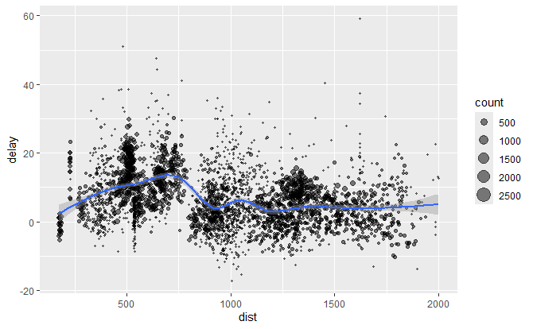

```r
library(ggplot2)
planes <- group_by(flights, tailnum)
delay <- summarise(planes,
  count = n(),
  dist = mean(distance, na.rm = TRUE),
  delay = mean(arr_delay, na.rm = TRUE))
delay <- filter(delay, count > 20, dist < 2000)

ggplot(delay, aes(dist, delay)) +
  geom_point(aes(size = count), alpha = 1/2) +
  geom_smooth() +
  scale_size_area()
```

### 7. Знайшов кількість літаків і кількість вильотів в усі можливі пункти призначення.

```r
destinations <- group_by(flights, dest)
summarise(destinations,
  planes = n_distinct(tailnum),
  flights = n()
)
```

| dest | planes | flights |
| --- | --- | --- |
| ABQ | 108 | 254 |
| ACK | 58 | 265 |
| ALB | 172 | 439 |
| ANC | 6 | 8 |
| ATL | 1180 | 17215 |
| AUS | 993 | 2439 |
| AVL | 159 | 275 |
| BDL | 186 | 443 |
| BGR | 46 | 375 |
| BHM | 45 | 297 |

[output cut: 95 more lines]

```r
DBI::dbDisconnect(connection)
```